# **Introduction**

## Libraries

```python
import pandas as pd
import numpy as np
import seaborn as sns
import matplotlib.pyplot as plt
import seaborn as sns
from sklearn.model_selection import train_test_split
from sklearn.preprocessing import StandardScaler
from matplotlib import pyplot
from matplotlib.pyplot import figure
from sklearn.ensemble import RandomForestClassifier
from sklearn.feature_selection import RFE
from sklearn.model_selection import ShuffleSplit
from sklearn.svm import SVC
from sklearn.datasets import load_digits
from sklearn.model_selection import learning_curve
from imblearn.pipeline import Pipeline as imbpipeline
from imblearn.over_sampling import SMOTE
from sklearn.linear_model import LogisticRegression
from sklearn.tree import DecisionTreeClassifier
!pip install lightgbm
from lightgbm import LGBMClassifier
from xgboost import XGBClassifier
from sklearn.model_selection import GridSearchCV
from sklearn.metrics import confusion_matrix
from sklearn import metrics
```

# **Data collection**

The data comes from kaggle, and you can find it at this original site below. https://www.kaggle.com/datasets/datasnaek/league-of-legends?resource=download

This data includes over 50,000 games from the EUW server, and also includes json files of champion code names in the original site, although data on used and banned heroes is outside the scope of our discussion of this data analysis. Since champion data and their total win rate in Riot's servers are constantly changing, and they make adjustments and changes to some heroes, it is pointless to discuss a 5 year old champion data.

There is something else in the raw data that we are not going to discuss, and that is summoner spell. Since each player's chosen summoner spell is related to their chosen hero and position and is relatively fixed, to avoid providing unnecessary redundant information, we will remove this data later in the data processing.

```python
games = pd.read_csv("/content/games.csv")
games.head()
```

|  | gameId | creationTime | gameDuration | seasonId | winner | firstBlood | firstTower | firstInhibitor | firstBaron | firstDragon | ... | t2_towerKills | t2_inhibitorKills | t2_baronKills | t2_dragonKills | t2_riftHeraldKills | t2_ban1 | t2_ban2 | t2_ban3 | t2_ban4 | t2_ban5 |
| --- | --- | --- | --- | --- | --- | --- | --- | --- | --- | --- | --- | --- | --- | --- | --- | --- | --- | --- | --- | --- | --- |
| 0 | 3326086514 | 1504279457970 | 1949 | 9 | 1 | 2 | 1 | 1 | 1 | 1 | ... | 5 | 0 | 0 | 1 | 1 | 114 | 67 | 43 | 16 | 51 |
| 1 | 3229566029 | 1497848803862 | 1851 | 9 | 1 | 1 | 1 | 1 | 0 | 1 | ... | 2 | 0 | 0 | 0 | 0 | 11 | 67 | 238 | 51 | 420 |
| 2 | 3327363504 | 1504360103310 | 1493 | 9 | 1 | 2 | 1 | 1 | 1 | 2 | ... | 2 | 0 | 0 | 1 | 0 | 157 | 238 | 121 | 57 | 28 |
| 3 | 3326856598 | 1504348503996 | 1758 | 9 | 1 | 1 | 1 | 1 | 1 | 1 | ... | 0 | 0 | 0 | 0 | 0 | 164 | 18 | 141 | 40 | 51 |
| 4 | 3330080762 | 1504554410899 | 2094 | 9 | 1 | 2 | 1 | 1 | 1 | 1 | ... | 3 | 0 | 0 | 1 | 0 | 86 | 11 | 201 | 122 | 18 |

5 rows × 61 columns

When cleaning the data, we should remove the gameID and creationTime data first, so that it is easier to find the data about duplication later.

Next, we need to remove the champion picked/banned by both teams. The season information should be removed as well.

It is important to note that the original data "winner" represents the winning team, but the numbers 1 and 2 will affect our plot_learning_curve function later, so here I use 0 to represent the first team failed, that is, the second team won.

```python
games = games.drop(["gameId", "creationTime"], axis = 1)
games = games.drop(["t1_champ1id", "t1_champ1_sum1", "t1_champ1_sum2", "t1_champ2id", "t1_champ2_sum1", "t1_champ2_sum2", "t1_champ3id", "t1_champ3_sum1", "t1_champ3_sum2", "t1_champ4id", "t1_champ4_sum1", "t1_champ4_sum2", "t1_champ5id", "t1_champ5_sum1", "t1_champ5_sum2"], axis = 1)
games = games.drop(["t2_champ1id", "t2_champ1_sum1", "t2_champ1_sum2", "t2_champ2id", "t2_champ2_sum1", "t2_champ2_sum2", "t2_champ3id", "t2_champ3_sum1", "t2_champ3_sum2", "t2_champ4id", "t2_champ4_sum1", "t2_champ4_sum2", "t2_champ5id", "t2_champ5_sum1", "t2_champ5_sum2"], axis = 1)
games = games.drop(["t1_ban1", "t1_ban2", "t1_ban3", "t1_ban4", "t1_ban5"], axis = 1)
games = games.drop(["t2_ban1", "t2_ban2", "t2_ban3", "t2_ban4", "t2_ban5"], axis = 1)
games = games.drop(["seasonId"], axis = 1)
games["winner"] = games["winner"].replace(2, 0)
games.head(10)
```

|  | gameDuration | winner | firstBlood | firstTower | firstInhibitor | firstBaron | firstDragon | firstRiftHerald | t1_towerKills | t1_inhibitorKills | t1_baronKills | t1_dragonKills | t1_riftHeraldKills | t2_towerKills | t2_inhibitorKills | t2_baronKills | t2_dragonKills | t2_riftHeraldKills |
| --- | --- | --- | --- | --- | --- | --- | --- | --- | --- | --- | --- | --- | --- | --- | --- | --- | --- | --- |
| 0 | 1949 | 1 | 2 | 1 | 1 | 1 | 1 | 2 | 11 | 1 | 2 | 3 | 0 | 5 | 0 | 0 | 1 | 1 |
| 1 | 1851 | 1 | 1 | 1 | 1 | 0 | 1 | 1 | 10 | 4 | 0 | 2 | 1 | 2 | 0 | 0 | 0 | 0 |
| 2 | 1493 | 1 | 2 | 1 | 1 | 1 | 2 | 0 | 8 | 1 | 1 | 1 | 0 | 2 | 0 | 0 | 1 | 0 |
| 3 | 1758 | 1 | 1 | 1 | 1 | 1 | 1 | 0 | 9 | 2 | 1 | 2 | 0 | 0 | 0 | 0 | 0 | 0 |
| 4 | 2094 | 1 | 2 | 1 | 1 | 1 | 1 | 0 | 9 | 2 | 1 | 3 | 0 | 3 | 0 | 0 | 1 | 0 |
| 5 | 2059 | 1 | 2 | 2 | 1 | 1 | 2 | 0 | 8 | 1 | 1 | 1 | 0 | 6 | 0 | 0 | 3 | 0 |
| 6 | 1993 | 1 | 1 | 2 | 1 | 1 | 1 | 1 | 10 | 2 | 1 | 2 | 1 | 2 | 0 | 0 | 0 | 0 |
| 7 | 1334 | 1 | 1 | 1 | 0 | 0 | 2 | 1 | 6 | 0 | 0 | 0 | 1 | 0 | 0 | 0 | 2 | 0 |
| 8 | 1387 | 0 | 2 | 2 | 2 | 0 | 2 | 2 | 0 | 0 | 0 | 0 | 0 | 8 | 1 | 0 | 2 | 1 |
| 9 | 2681 | 0 | 2 | 2 | 2 | 2 | 2 | 0 | 10 | 1 | 0 | 2 | 0 | 8 | 3 | 1 | 2 | 0 |

All the data types in this dataset are integers, but some of them just appear to be quantitative, but are actually qualitative data. For example, "firstBlood" shows the number corresponding to the team that got it, which is more like a boolean type.

We consider the following as quantitative （by exactly how many） data that can be used to find data correlation: "gameDuration", "winner", "t1_towerKills", "t1_inhibitorKills", "t1_baronKills", "t1*dragonKills", "t1* riftHeraldKills", "t2_towerKills", "t2_inhibitorKills", "t2_baronKills", "t2_dragonKills", "t2_riftHeraldKills"

It is also worth mentioning that in these more than 50,000 matchups, the probability of both teams winning is relatively balanced, i.e. both are close to 50%. For example, the "Nexus" of the first team (blue team) is in the bottom left corner of the map, while the player needs to destroy the "Nexus" of the top right team. The location of the jungle also changes, for example, the blue buff of the blue team is in the top half of the map （Team1 top jungle）, while the blue buff of the red team is in the bottom half (Team2 bottom jungle). This "mirroring" difference has many implications for the content of the game. For example, many junglers need to choose blue buff to start the game, if both junglers choose blue buff to start the game, then after getting blue buff, they will choose to go to the other side of the map, as a result, the blue team jungler will choose to gank in the top lane, while the red team jungler will choose to gank in the bottom lane. This means that the blue team's top lane will be at a disadvantage at the start of the game (ganked by the red team's jungler), while the red team's bottom lane will be at a disadvantage at the start of the game (ganked by the blue team's jungler). This "mirror" pattern can easily lead to an uneven win rate for both teams if the top and bottom lanes have different levels of influence on the game.

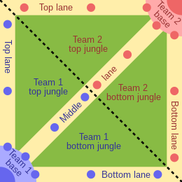

This image is from wikiPedia, here's the URL.

https://en.wikipedia.org/wiki/File:Map_of_MOBA.svg

Fortunately, the mean shown in these win rates give a good indication that the probability of winning for both teams is considered infinitely close. (Of course, very few game companies set their teams' win rates too far to each other.) So here we consider both teams to have the same initial conditions.

```python
quantitative_games = games[["gameDuration", "winner", "t1_towerKills", "t1_inhibitorKills", "t1_baronKills", "t1_dragonKills", "t1_riftHeraldKills", "t2_towerKills", "t2_inhibitorKills", "t2_baronKills", "t2_dragonKills", "t2_riftHeraldKills"]]
quantitative_games.describe(include = "all")
```

|  | gameDuration | winner | t1_towerKills | t1_inhibitorKills | t1_baronKills | t1_dragonKills | t1_riftHeraldKills | t2_towerKills | t2_inhibitorKills | t2_baronKills | t2_dragonKills | t2_riftHeraldKills |
| --- | --- | --- | --- | --- | --- | --- | --- | --- | --- | --- | --- | --- |
| count | 51490.000000 | 51490.000000 | 51490.000000 | 51490.000000 | 51490.000000 | 51490.000000 | 51490.000000 | 51490.000000 | 51490.000000 | 51490.000000 | 51490.000000 | 51490.000000 |
| mean | 1832.362808 | 0.506448 | 5.699359 | 1.017537 | 0.372286 | 1.387182 | 0.251466 | 5.549466 | 0.985084 | 0.414547 | 1.404370 | 0.240105 |
| std | 512.017696 | 0.499963 | 3.799808 | 1.263934 | 0.583934 | 1.206818 | 0.433860 | 3.860989 | 1.256284 | 0.613768 | 1.224492 | 0.427151 |
| min | 190.000000 | 0.000000 | 0.000000 | 0.000000 | 0.000000 | 0.000000 | 0.000000 | 0.000000 | 0.000000 | 0.000000 | 0.000000 | 0.000000 |
| 25% | 1531.000000 | 0.000000 | 2.000000 | 0.000000 | 0.000000 | 0.000000 | 0.000000 | 2.000000 | 0.000000 | 0.000000 | 0.000000 | 0.000000 |
| 50% | 1833.000000 | 1.000000 | 6.000000 | 1.000000 | 0.000000 | 1.000000 | 0.000000 | 6.000000 | 0.000000 | 0.000000 | 1.000000 | 0.000000 |
| 75% | 2148.000000 | 1.000000 | 9.000000 | 2.000000 | 1.000000 | 2.000000 | 1.000000 | 9.000000 | 2.000000 | 1.000000 | 2.000000 | 0.000000 |
| max | 4728.000000 | 1.000000 | 11.000000 | 10.000000 | 5.000000 | 6.000000 | 1.000000 | 11.000000 | 10.000000 | 4.000000 | 6.000000 | 1.000000 |

```python
games
```

|  | gameDuration | winner | firstBlood | firstTower | firstInhibitor | firstBaron | firstDragon | firstRiftHerald | t1_towerKills | t1_inhibitorKills | t1_baronKills | t1_dragonKills | t1_riftHeraldKills | t2_towerKills | t2_inhibitorKills | t2_baronKills | t2_dragonKills | t2_riftHeraldKills |
| --- | --- | --- | --- | --- | --- | --- | --- | --- | --- | --- | --- | --- | --- | --- | --- | --- | --- | --- |
| 0 | 1949 | 1 | 2 | 1 | 1 | 1 | 1 | 2 | 11 | 1 | 2 | 3 | 0 | 5 | 0 | 0 | 1 | 1 |
| 1 | 1851 | 1 | 1 | 1 | 1 | 0 | 1 | 1 | 10 | 4 | 0 | 2 | 1 | 2 | 0 | 0 | 0 | 0 |
| 2 | 1493 | 1 | 2 | 1 | 1 | 1 | 2 | 0 | 8 | 1 | 1 | 1 | 0 | 2 | 0 | 0 | 1 | 0 |
| 3 | 1758 | 1 | 1 | 1 | 1 | 1 | 1 | 0 | 9 | 2 | 1 | 2 | 0 | 0 | 0 | 0 | 0 | 0 |
| 4 | 2094 | 1 | 2 | 1 | 1 | 1 | 1 | 0 | 9 | 2 | 1 | 3 | 0 | 3 | 0 | 0 | 1 | 0 |
| ... | ... | ... | ... | ... | ... | ... | ... | ... | ... | ... | ... | ... | ... | ... | ... | ... | ... | ... |
| 51485 | 1944 | 0 | 1 | 2 | 2 | 0 | 2 | 0 | 2 | 0 | 0 | 0 | 0 | 10 | 2 | 0 | 4 | 0 |
| 51486 | 3304 | 0 | 1 | 1 | 2 | 2 | 2 | 2 | 5 | 4 | 0 | 2 | 0 | 11 | 7 | 4 | 4 | 1 |
| 51487 | 2156 | 0 | 2 | 2 | 2 | 0 | 1 | 0 | 0 | 0 | 0 | 1 | 0 | 10 | 2 | 0 | 2 | 0 |
| 51488 | 1475 | 0 | 2 | 2 | 2 | 0 | 2 | 0 | 0 | 0 | 0 | 0 | 0 | 11 | 3 | 0 | 1 | 0 |
| 51489 | 1445 | 1 | 1 | 1 | 1 | 1 | 2 | 0 | 11 | 3 | 1 | 2 | 0 | 1 | 0 | 0 | 1 | 0 |

51490 rows × 18 columns

```python
games.drop_duplicates(keep = False, inplace = True)
duCount = games.duplicated().sum()
print("Num of dups: ", duCount)
```

```
Num of dups:  0
```

```python
games.isnull().sum()
```

```
gameDuration          0
winner                0
firstBlood            0
firstTower            0
firstInhibitor        0
firstBaron            0
firstDragon           0
firstRiftHerald       0
t1_towerKills         0
t1_inhibitorKills     0
t1_baronKills         0
t1_dragonKills        0
t1_riftHeraldKills    0
t2_towerKills         0
t2_inhibitorKills     0
t2_baronKills         0
t2_dragonKills        0
t2_riftHeraldKills    0
dtype: int64
```

# **Exploratory data analysis**

```python
# Skewness check
print("\n SKEWNESS\n",quantitative_games.skew())
quantitative_games.groupby("winner").mean()
```

```
 SKEWNESS
 gameDuration         -0.308379
winner               -0.025794
t1_towerKills        -0.093616
t1_inhibitorKills     1.208771
t1_baronKills         1.428661
t1_dragonKills        0.556431
t1_riftHeraldKills    1.145730
t2_towerKills        -0.043917
t2_inhibitorKills     1.268242
t2_baronKills         1.330474
t2_dragonKills        0.535247
t2_riftHeraldKills    1.216924
dtype: float64
```

| winner | gameDuration | t1_towerKills | t1_inhibitorKills | t1_baronKills | t1_dragonKills | t1_riftHeraldKills | t2_towerKills | t2_inhibitorKills | t2_baronKills | t2_dragonKills | t2_riftHeraldKills |
| --- | --- | --- | --- | --- | --- | --- | --- | --- | --- | --- | --- |
| 0 | 1844.907567 | 2.729627 | 0.186086 | 0.153740 | 0.809586 | 0.155629 | 8.622831 | 1.825562 | 0.662771 | 2.021092 | 0.337937 |
| 1 | 1820.137477 | 8.593473 | 1.827818 | 0.585267 | 1.950071 | 0.344863 | 2.554358 | 0.166008 | 0.172643 | 0.803352 | 0.144764 |

```python
# skewness correction
import scipy.stats as ss
import math

def skew_autotransform(DF, include = None, exclude = None, plot = False, threshold = 1, exp = False):

    #Get list of column names that should be processed based on input parameters
    if include is None and exclude is None:
        colnames = DF.columns.values
    elif include is not None:
        colnames = include
    elif exclude is not None:
        colnames = [item for item in list(DF.columns.values) if item not in exclude]
    else:
        print('No columns to process!')

    #Helper function that checks if all values are positive
    def make_positive(series):
        minimum = np.amin(series)
        #If minimum is negative, offset all values by a constant to move all values to positive teritory
        if minimum <= 0:
            series = series + abs(minimum) + 0.01
        return series


    #Go through desired columns in DataFrame
    for col in colnames:
        #Get column skewness
        skew = DF[col].skew()
        transformed = True

        if plot:
            #Prep the plot of original data
            sns.set_style("darkgrid")
            sns.set_palette("Blues_r")
            fig, axes = plt.subplots(1, 2, figsize=(10, 5))
            #ax1 = sns.distplot(DF[col], ax=axes[0])
            ax1 = sns.histplot(DF[col], ax=axes[0], color="blue", label="100% Equities", kde=True, stat="density", linewidth=0)
            ax1.set(xlabel='Original ' + str(col))

        #If skewness is larger than threshold and positively skewed; If yes, apply appropriate transformation
        if abs(skew) > threshold and skew > 0:
            skewType = 'positive'
            #Make sure all values are positive
            DF[col] = make_positive(DF[col])

            if exp:
               #Apply log transformation
               DF[col] = DF[col].apply(math.log)
            else:
                #Apply boxcox transformation
                DF[col] = ss.boxcox(DF[col])[0]
            skew_new = DF[col].skew()

        elif abs(skew) > threshold and skew < 0:
            skewType = 'negative'
            #Make sure all values are positive
            DF[col] = make_positive(DF[col])

            if exp:
               #Apply exp transformation
               DF[col] = DF[col].pow(10)
            else:
                #Apply boxcox transformation
                DF[col] = ss.boxcox(DF[col])[0]
            skew_new = DF[col].skew()

        else:
            #Flag if no transformation was performed
            transformed = False
            skew_new = skew

        #Compare before and after if plot is True
        if plot:
            print('\n ------------------------------------------------------')
            if transformed:
                print('\n %r had %r skewness of %2.2f' %(col, skewType, skew))
                print('\n Transformation yielded skewness of %2.2f' %(skew_new))
                sns.set_palette("Paired")
                #ax2 = sns.distplot(DF[col], ax=axes[1], color = 'r')
                ax2 = sns.histplot(DF[col], ax=axes[1], color="red", label="100% Equities", kde=True, stat="density", linewidth=0)
                ax2.set(xlabel='Transformed ' + str(col))
                plt.show()
            else:
                print('\n NO TRANSFORMATION APPLIED FOR %r . Skewness = %2.2f' %(col, skew))
                #ax2 = sns.distplot(DF[col], ax=axes[1])
                ax2 = sns.histplot(DF[col], ax=axes[1], color="blue", label="100% Equities", kde=True, stat="density", linewidth=0)
                ax2.set(xlabel='NO TRANSFORM ' + str(col))
                plt.show()


    return DF

    df = skew_autotransform(quantitative_games.copy(deep=True), include=["t1_inhibitorKills","t1_baronKills","t1_riftHeraldKills","t2_inhibitorKills","t2_baronKills","t2_riftHeraldKills"],plot = False, exp = False, threshold = 1)
```

## Correlation

```
CORRELATION MATRIX
                     gameDuration    winner  firstBlood  firstTower  \
gameDuration            1.000000 -0.023471    0.009782    0.026214
winner                 -0.023471  1.000000   -0.175842   -0.409945
firstBlood              0.009782 -0.175842    1.000000    0.205969
firstTower              0.026214 -0.409945    0.205969    1.000000
firstInhibitor          0.278389 -0.568139    0.121234    0.300079
firstBaron              0.468808 -0.266159    0.044912    0.105845
firstDragon             0.087735 -0.332365    0.123575    0.290310
firstRiftHerald        -0.062909 -0.119959    0.058471    0.144373
t1_towerKills           0.306373  0.802275   -0.184057   -0.454852
t1_inhibitorKills       0.281046  0.663093   -0.128416   -0.316931
t1_baronKills           0.401819  0.378224   -0.053108   -0.105984
t1_dragonKills          0.377361  0.483894   -0.122932   -0.298205
t1_riftHeraldKills     -0.039746  0.219172   -0.102750   -0.243862
t2_towerKills           0.337492 -0.813143    0.189881    0.471289
t2_inhibitorKills       0.299727 -0.672488    0.132351    0.327710
t2_baronKills           0.435138 -0.404185    0.057394    0.130353
t2_dragonKills          0.384727 -0.506579    0.131521    0.323031
t2_riftHeraldKills     -0.040049 -0.225970    0.108074    0.261858

                    firstInhibitor  firstBaron  firstDragon  firstRiftHerald  \
gameDuration              0.278389    0.468808     0.087735        -0.062909
winner                   -0.568139   -0.266159    -0.332365        -0.119959
firstBlood                0.121234    0.044912     0.123575         0.058471
firstTower                0.300079    0.105845     0.290310         0.144373
firstInhibitor            1.000000    0.387017     0.270502         0.132256
firstBaron                0.387017    1.000000     0.148946         0.099540
firstDragon               0.270502    0.148946     1.000000         0.116970
firstRiftHerald           0.132256    0.099540     0.116970         1.000000
t1_towerKills            -0.372891   -0.042732    -0.302966        -0.117631
t1_inhibitorKills        -0.326125   -0.047224    -0.227430        -0.077220
t1_baronKills            -0.113865    0.117709    -0.087881        -0.004654
t1_dragonKills           -0.227514    0.055053    -0.496946        -0.082272
t1_riftHeraldKills       -0.133260   -0.023716    -0.143932         0.178407
t2_towerKills             0.741096    0.437447     0.376575         0.161571
t2_inhibitorKills         0.700198    0.371333     0.273597         0.126110
t2_baronKills             0.386529    0.790601     0.167232         0.087440
t2_dragonKills            0.461047    0.372413     0.617492         0.127775
t2_riftHeraldKills        0.194165    0.107294     0.184948         0.866570
```

[output cut: 65 more lines]

```
firstTower                    0.261858
firstInhibitor                0.194165
firstBaron                    0.107294
firstDragon                   0.184948
firstRiftHerald               0.866570
t1_towerKills                -0.249195
t1_inhibitorKills            -0.175508
t1_baronKills                -0.061299
t1_dragonKills               -0.174726
t1_riftHeraldKills           -0.336447
t2_towerKills                 0.275377
t2_inhibitorKills             0.206046
t2_baronKills                 0.114598
t2_dragonKills                0.205715
t2_riftHeraldKills            1.000000
```

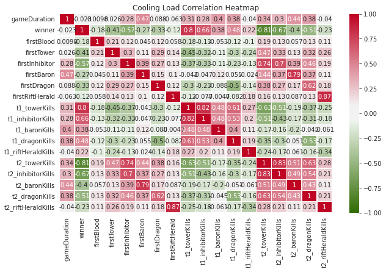

```
Quantitative CORRELATION MATRIX
                     gameDuration    winner  t1_towerKills  t1_inhibitorKills  \
gameDuration            1.000000 -0.024187       0.369478           0.301616
winner                 -0.024187  1.000000       0.771541           0.649405
t1_towerKills           0.369478  0.771541       1.000000           0.824471
t1_inhibitorKills       0.301616  0.649405       0.824471           1.000000
t1_baronKills           0.397987  0.369472       0.490723           0.481606
t1_dragonKills          0.409414  0.472483       0.626743           0.538469
t1_riftHeraldKills      0.006769  0.218066       0.283925           0.210728
t2_towerKills           0.396769 -0.785813      -0.549123          -0.467867
t2_inhibitorKills       0.319451 -0.660452      -0.469600          -0.408924
t2_baronKills           0.429793 -0.399249      -0.158556          -0.153026
t2_dragonKills          0.416995 -0.497206      -0.313789          -0.279089
t2_riftHeraldKills      0.007818 -0.226102      -0.224888          -0.164355

                    t1_baronKills  t1_dragonKills  t1_riftHeraldKills  \
gameDuration             0.397987        0.409414            0.006769
winner                   0.369472        0.472483            0.218066
t1_towerKills            0.490723        0.626743            0.283925
t1_inhibitorKills        0.481606        0.538469            0.210728
t1_baronKills            1.000000        0.409380            0.119870
t1_dragonKills           0.409380        1.000000            0.203930
t1_riftHeraldKills       0.119870        0.203930            1.000000
t2_towerKills           -0.144271       -0.303139           -0.214717
t2_inhibitorKills       -0.146382       -0.269714           -0.157812
t2_baronKills           -0.189526       -0.033048           -0.053136
t2_dragonKills          -0.027525       -0.486093           -0.149586
t2_riftHeraldKills      -0.053148       -0.159509           -0.325805

                    t2_towerKills  t2_inhibitorKills  t2_baronKills  \
gameDuration             0.396769           0.319451       0.429793
winner                  -0.785813          -0.660452      -0.399249
t1_towerKills           -0.549123          -0.469600      -0.158556
t1_inhibitorKills       -0.467867          -0.408924      -0.153026
t1_baronKills           -0.144271          -0.146382      -0.189526
t1_dragonKills          -0.303139          -0.269714      -0.033048
t1_riftHeraldKills      -0.214717          -0.157812      -0.053136
t2_towerKills            1.000000           0.825834       0.522166
t2_inhibitorKills        0.825834           1.000000       0.499613
t2_baronKills            0.522166           0.499613       1.000000
t2_dragonKills           0.648020           0.548134       0.444655
t2_riftHeraldKills       0.290283           0.216553       0.124451

                    t2_dragonKills  t2_riftHeraldKills
gameDuration              0.416995            0.007818
winner                   -0.497206           -0.226102
t1_towerKills            -0.313789           -0.224888
t1_inhibitorKills        -0.279089           -0.164355
t1_baronKills            -0.027525           -0.053148
t1_dragonKills           -0.486093           -0.159509
t1_riftHeraldKills       -0.149586           -0.325805
t2_towerKills             0.648020            0.290283
t2_inhibitorKills         0.548134            0.216553
t2_baronKills             0.444655            0.124451
t2_dragonKills            1.000000            0.220556
t2_riftHeraldKills        0.220556            1.000000
```

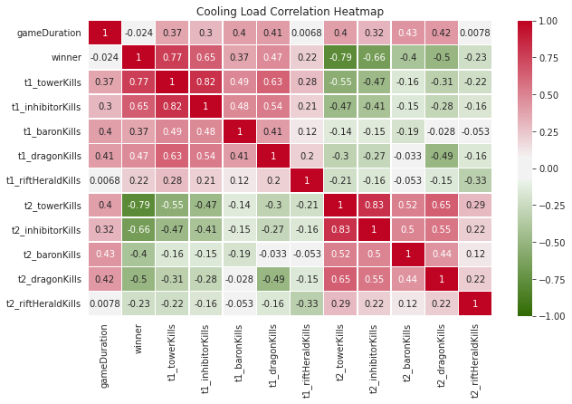

```python
print("CORRELATION MATRIX\n", games.corr())
print("\n\n")

sns.set_style('darkgrid')
plt.figure(figsize = (10,6))
cmap = sns.diverging_palette(120, 10, l = 40, s = 99, sep = 20, center = 'light', as_cmap = True)
sns.heatmap((games).corr(), vmin = -1, vmax = 1, annot = True, cmap = cmap, lw = .5, linecolor = 'white')
plt.title("Cooling Load Correlation Heatmap")
plt.show()

print("Quantitative CORRELATION MATRIX\n", quantitative_games.corr())
print("\n\n")

sns.set_style('darkgrid')
plt.figure(figsize = (10,6))
cmap = sns.diverging_palette(120, 10, l = 40, s = 99, sep = 20, center = 'light', as_cmap = True)
sns.heatmap((quantitative_games).corr(), vmin = -1, vmax = 1, annot = True, cmap = cmap, lw = .5, linecolor = 'white')
plt.title("Cooling Load Correlation Heatmap")
plt.show()
```

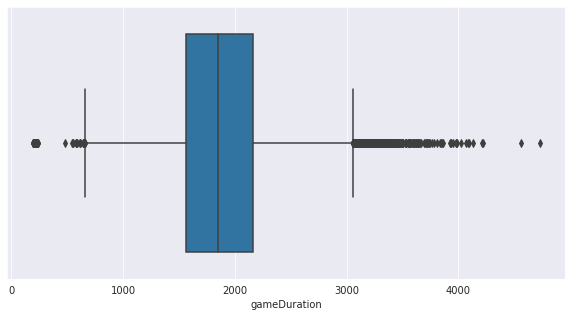

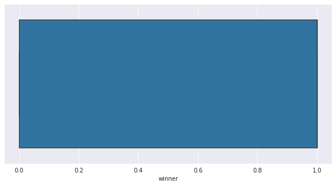

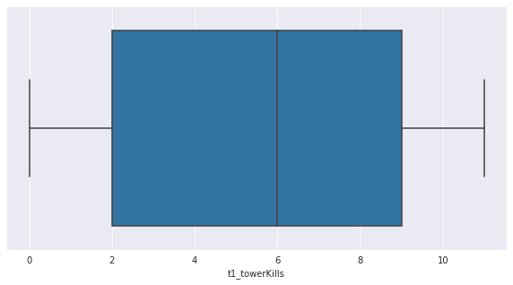

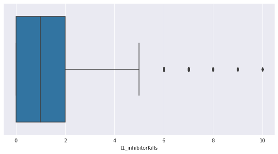

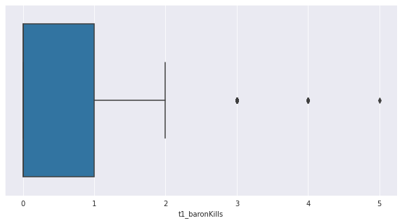

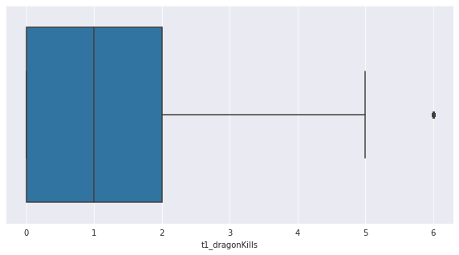

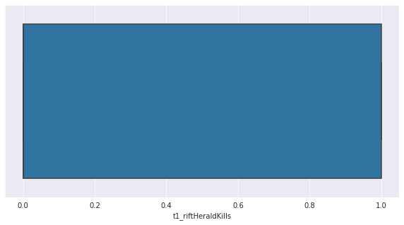

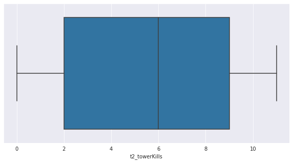

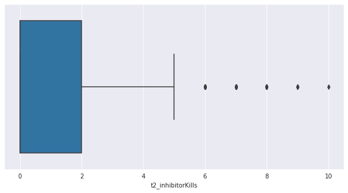

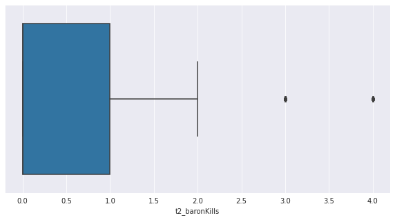

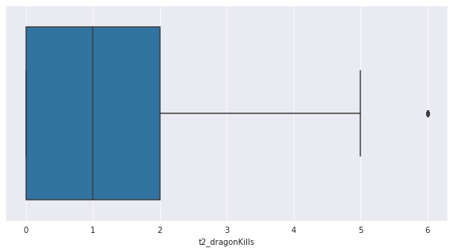

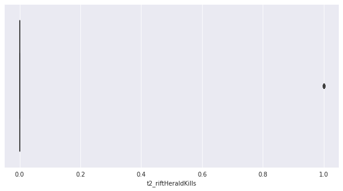

```python
# Outlier detection in quant varianbles
for i in quantitative_games.columns:
  if games.dtypes[i] == 'int64' or games.dtypes[i] == 'float64':
    plt.figure(figsize = (10,5))
    sns.boxplot(games[i])
    plt.show()
```

# **Hypothesis testing**

```python
# seperate
X = games.drop(["winner"],axis=1)
y = games["winner"]


X_train, X_test, y_train, y_test =\
    train_test_split(X, y,
                     test_size=0.2,    # 80-20 training vs test set split
                     random_state=0)
print('Shape of X and y',X.shape, y.shape, '\nShape of training set X and y',
      X_train.shape, y_train.shape, '\nShape of test set X and y',
      X_test.shape, y_test.shape)
```

```
Shape of X and y (48992, 17) (48992,)
Shape of training set X and y (39193, 17) (39193,)
Shape of test set X and y (9799, 17) (9799,)
```

## Scaling

```python
stdsc1 = StandardScaler()
X_train_std = stdsc1.fit_transform(X_train)
X_test_std = stdsc1.transform(X_test)

y_train=pd.DataFrame(y_train)
y_test=pd.DataFrame(y_test)

stdsc2 = StandardScaler()
y_train_std = stdsc2.fit_transform(y_train)
y_test_std = stdsc2.transform(y_test)
```

## Feature Importance

```
<BarContainer object of 17 artists>
```

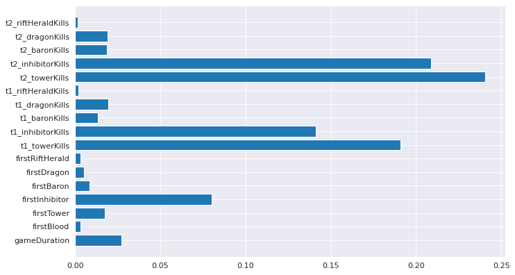

```python
# Code adapted from this source: https://machinelearningmastery.com/calculate-feature-importance-with-python/
figure(figsize=(10, 6), dpi=80)

col_names = X_train.columns

model = RandomForestClassifier()
# fit the model
model.fit(X_train_std, y_train)
# get importance
importance = model.feature_importances_
# summarize feature importance
plt.barh(col_names, model.feature_importances_)
```

```python
rfe = RFE(estimator=LGBMClassifier(), n_features_to_select=8)    #Selecting the top n features, from about 70, to improve model robustness.
_ = rfe.fit(X_train_std,y_train)
print('Important Features\n',X_train.columns[rfe.support_])
rf = XGBClassifier()
_ = rf.fit(rfe.transform(X_train_std), y_train)
print("\n Accuracy: ",rf.score(rfe.transform(X_test_std), y_test))
```

[output not shown]

```
Important Features
 Index(['gameDuration', 'firstInhibitor', 't1_towerKills', 't1_inhibitorKills',
       't2_towerKills', 't2_inhibitorKills', 't2_baronKills',
       't2_dragonKills'],
      dtype='object')
```

```
 Accuracy:  0.9780589856107766
```

```python
X = X[['firstBlood', 'gameDuration', 'firstInhibitor', 't1_towerKills', 't1_inhibitorKills',
       't2_towerKills', 't2_inhibitorKills', 't2_baronKills',
       't2_dragonKills']]
```

```
Scores: [0.97054121 0.97135762 0.97149369 0.9713236  0.9711195 ] [0.00103515 0.00125357 0.00097647 0.00088182 0.00094638]
```

```
Scores: [0.96503045 0.96880634 0.96897643 0.97026908 0.97067728] [0.00070867 0.00075607 0.00136408 0.00165464 0.0020953 ]
```

```
Scores: [0.97288839 0.97724258 0.97812702 0.97829711 0.97894343] [0.00091404 0.00108961 0.00133406 0.00143438 0.00155067]
```

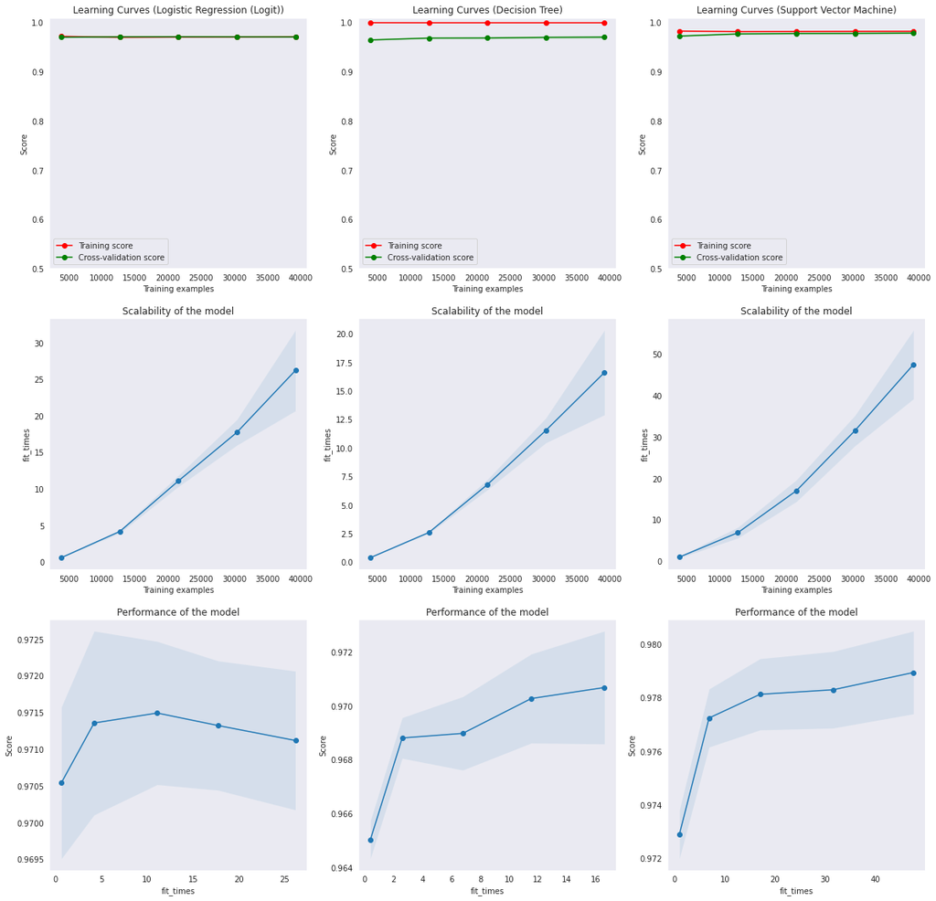

```
Scores: [0.97836514 0.9802701  0.98023608 0.98010001 0.97996394] [0.00091657 0.00107464 0.00056718 0.00082065 0.0007184 ]
Scores: [0.97632411 0.97969181 0.97952172 0.98020206 0.98003198] [0.00159627 0.00116654 0.00112514 0.00167273 0.00133666]
Scores: [0.97663027 0.97996394 0.98033813 0.9816648  0.98152873] [0.00084565 0.00118231 0.00084291 0.00058525 0.00066137]
```

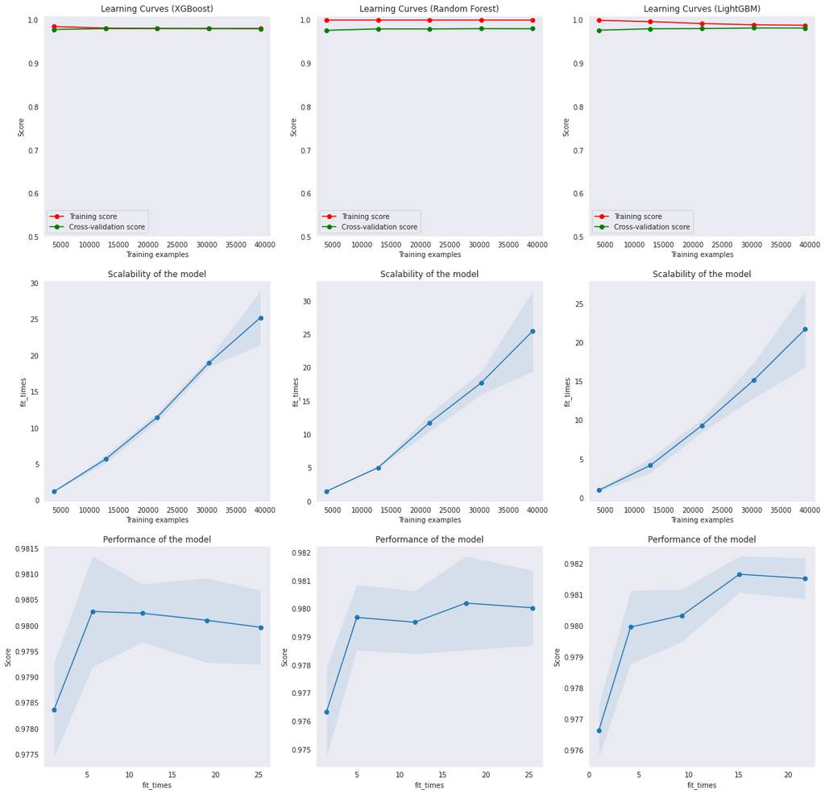

```python
def plot_learning_curve(
    estimator,
    title,
    X,
    y,
    axes=None,
    ylim=None,
    cv=None,
    n_jobs=None,
    scoring = 'roc_auc_score',
    train_sizes=np.linspace(0.1, 1.0, 5),
):
    """
    Generate 3 plots: the test and training learning curve, the training
    samples vs fit times curve, the fit times vs score curve.

    Parameters
    ----------
    estimator : estimator instance
        An estimator instance implementing `fit` and `predict` methods which
        will be cloned for each validation.

    title : str
        Title for the chart.

    X : array-like of shape (n_samples, n_features)
        Training vector, where ``n_samples`` is the number of samples and
        ``n_features`` is the number of features.

    y : array-like of shape (n_samples) or (n_samples, n_features)
        Target relative to ``X`` for classification or regression;
        None for unsupervised learning.

    axes : array-like of shape (3,), default=None
        Axes to use for plotting the curves.

    ylim : tuple of shape (2,), default=None
        Defines minimum and maximum y-values plotted, e.g. (ymin, ymax).

    cv : int, cross-validation generator or an iterable, default=None
        Determines the cross-validation splitting strategy.
        Possible inputs for cv are:

          - None, to use the default 5-fold cross-validation,
          - integer, to specify the number of folds.
          - :term:`CV splitter`,
          - An iterable yielding (train, test) splits as arrays of indices.

        For integer/None inputs, if ``y`` is binary or multiclass,
        :class:`StratifiedKFold` used. If the estimator is not a classifier
        or if ``y`` is neither binary nor multiclass, :class:`KFold` is used.

        Refer :ref:`User Guide <cross_validation>` for the various
        cross-validators that can be used here.

    n_jobs : int or None, default=None
        Number of jobs to run in parallel.
        ``None`` means 1 unless in a :obj:`joblib.parallel_backend` context.
        ``-1`` means using all processors. See :term:`Glossary <n_jobs>`
        for more details.

    train_sizes : array-like of shape (n_ticks,)
        Relative or absolute numbers of training examples that will be used to
        generate the learning curve. If the ``dtype`` is float, it is regarded
        as a fraction of the maximum size of the training set (that is
        determined by the selected validation method), i.e. it has to be within
        (0, 1]. Otherwise it is interpreted as absolute sizes of the training
        sets. Note that for classification the number of samples usually have
        to be big enough to contain at least one sample from each class.
        (default: np.linspace(0.1, 1.0, 5))
    """
    if axes is None:
        _, axes = plt.subplots(1, 3, figsize=(20, 5))

    axes[0].set_title(title)
    if ylim is not None:
        axes[0].set_ylim(*ylim)
    axes[0].set_xlabel("Training examples")
    axes[0].set_ylabel("Score")

    train_sizes, train_scores, test_scores, fit_times, _ = learning_curve(
        estimator,
        X,
        y,
        cv=cv,
        n_jobs=n_jobs,
        train_sizes=train_sizes,
        return_times=True,
    )
    train_scores_mean = np.mean(train_scores, axis=1)
    train_scores_std = np.std(train_scores, axis=1)
    test_scores_mean = np.mean(test_scores, axis=1)
    test_scores_std = np.std(test_scores, axis=1)
    fit_times_mean = np.mean(fit_times, axis=1)
    fit_times_std = np.std(fit_times, axis=1)
    print('Scores:',test_scores_mean,test_scores_std)

    # Plot learning curve
    axes[0].grid()
    axes[0].fill_between(
        train_sizes,
        train_scores_mean - train_scores_std,
        train_scores_mean + train_scores_std,
        alpha=0.1,
        color="r",
    )
    axes[0].fill_between(
        train_sizes,
        test_scores_mean - test_scores_std,
        test_scores_mean + test_scores_std,
        alpha=0.1,
        color="g",
    )
    axes[0].plot(
        train_sizes, train_scores_mean, "o-", color="r", label="Training score"
    )
    axes[0].plot(
        train_sizes, test_scores_mean, "o-", color="g", label="Cross-validation score"
    )
    axes[0].legend(loc="best")

    # Plot n_samples vs fit_times
    axes[1].grid()
    axes[1].plot(train_sizes, fit_times_mean, "o-")
    axes[1].fill_between(
        train_sizes,
        fit_times_mean - fit_times_std,
        fit_times_mean + fit_times_std,
        alpha=0.1,
    )
    axes[1].set_xlabel("Training examples")
    axes[1].set_ylabel("fit_times")
    axes[1].set_title("Scalability of the model")

    # Plot fit_time vs score
    fit_time_argsort = fit_times_mean.argsort()
    fit_time_sorted = fit_times_mean[fit_time_argsort]
    test_scores_mean_sorted = test_scores_mean[fit_time_argsort]
    test_scores_std_sorted = test_scores_std[fit_time_argsort]
    axes[2].grid()
    axes[2].plot(fit_time_sorted, test_scores_mean_sorted, "o-")
    axes[2].fill_between(
        fit_time_sorted,
        test_scores_mean_sorted - test_scores_std_sorted,
        test_scores_mean_sorted + test_scores_std_sorted,
        alpha=0.1,
    )
    axes[2].set_xlabel("fit_times")
    axes[2].set_ylabel("Score")
    axes[2].set_title("Performance of the model")

    return plt


fig, axes = plt.subplots(3, 3, figsize=(20, 20))

title = "Learning Curves (Logistic Regression (Logit))"
# Cross validation with 50 iterations to get smoother mean test and train
# score curves, each time with 20% data randomly selected as a validation set.
cv = ShuffleSplit(n_splits=3, test_size=0.2, random_state=0)
# estimator = kNeighborsClassifier()
estimator = imbpipeline(steps = [['smote', SMOTE(random_state=11)],
                                ['scaler', StandardScaler()],
                                ['classifier', LogisticRegression(random_state=11,
                                                                  max_iter=1000)]])
plot_learning_curve(
    estimator, title, X, y, axes=axes[:, 0], ylim=(0.5, 1.01), cv=cv, n_jobs=4
)


title = "Learning Curves (Decision Tree)"
cv = ShuffleSplit(n_splits=3, test_size=0.2, random_state=0)
estimator = imbpipeline(steps = [['smote', SMOTE(random_state=11)],
                                ['scaler', StandardScaler()],
                                ['classifier', DecisionTreeClassifier()]])
plot_learning_curve(
    estimator, title, X, y, axes=axes[:, 1], ylim=(0.5, 1.01), cv=cv, n_jobs=4
)


title = "Learning Curves (Support Vector Machine)"
cv = ShuffleSplit(n_splits=3, test_size=0.2, random_state=0)
estimator = imbpipeline(steps = [['smote', SMOTE(random_state=11)],
                                ['scaler', StandardScaler()],
                                ['classifier', SVC()]])
plot_learning_curve(
    estimator, title, X, y, axes=axes[:, 2], ylim=(0.5, 1.01), cv=cv, n_jobs=4
)

plt.show()

fig, axes = plt.subplots(3, 3, figsize=(20, 20))

title = "Learning Curves (XGBoost)"
# Cross validation with 50 iterations to get smoother mean test and train
# score curves, each time with 20% data randomly selected as a validation set.
cv = ShuffleSplit(n_splits=3, test_size=0.2, random_state=0)
estimator = imbpipeline(steps = [['smote', SMOTE(random_state=11)],
                                ['scaler', StandardScaler()],
                                ['classifier', XGBClassifier(random_state=11)]])
plot_learning_curve(
    estimator, title, X, y, axes=axes[:, 0], ylim=(0.5, 1.01), cv=cv, n_jobs=4
)


title = "Learning Curves (Random Forest)"
cv = ShuffleSplit(n_splits=3, test_size=0.2, random_state=0)
#estimator = RandomForestClassifier()
estimator = imbpipeline(steps = [['smote', SMOTE(random_state=11)],
                                ['scaler', StandardScaler()],
                                ['classifier', RandomForestClassifier()]])
plot_learning_curve(
    estimator, title, X, y, axes=axes[:, 1], ylim=(0.5, 1.01), cv=cv, n_jobs=4
)


title = "Learning Curves (LightGBM)"
cv = ShuffleSplit(n_splits=3, test_size=0.2, random_state=0)
# estimator = LGBMClassifier()
estimator = imbpipeline(steps = [['smote', SMOTE(random_state=11)],
                                ['scaler', StandardScaler()],
                                ['classifier', LGBMClassifier()]])
plot_learning_curve(
    estimator, title, X, y, axes=axes[:, 2], ylim=(0.5, 1.01), cv=cv, n_jobs=4
)

plt.show()
```